# Data Analyst ND P2 | Intro to Data Analysis | Investigate Titanic Data Set

Throughout this project, we will investigate Titanic Data to find out what factors made people more likely to survive? More likely we are looking for correlation between other data features and survivability (passenger) from data provided. We neither try to draw a causation, nor to provide an accurate prediction estimate through a machine learning model, such as linear regression.

Titanic Data set source: https://www.udacity.com/api/nodes/5420148578/supplemental_media/titanic-datacsv/download

Summary of Data set:

#### Total records: 891

#### Main features (columns) of each record:

```
(from the Kaggle website: https://www.kaggle.com/c/titanic/data)
    VARIABLE (column)     DESCRIPTIONS:
    PassengerId           Scalar number
    Survived              Survival
                                  (0 = No; 1 = Yes)
    Pclass                Passenger Class
                                  (1 = 1st/Upper; 2 = 2nd/Middle; 3 = 3rd/Lower)
    Name                  Name
    Sex                   Gender
    Age                   Age
    SibSp                 Number of Siblings/Spouses Aboard
    Parch                 Number of Parents/Children Aboard
    Ticket                Ticket Number
    Fare                  Passenger Fare
    Cabin                 Cabin
    Embarked              Port of Embarkation
                                  (C = Cherbourg; Q = Queenstown; S = Southampton)
```

### 1. Heuristic questions to ask from this Titanic data, and key question to research

This Titanic data may disclose correlations from multiple aspects, strong or weak, some are obvious but less interesting (e.g. Pclass and Fare may have very strong correlation, but little in value of research), while others are less obvious but very valuable to find out, one of this question is:

```
    What features (column variables) may made the passenger more likely to survive?
```

As of this time, we are not exploring correlations between a result (Y) and multiple independent variables (X1, ..., Xn), we will do that in machine learning project. So here we deduce the goal of this project to:

```
    What are the correlations between two variables - 'Survived' and one another variable?
    How do we present and calculate these correlations?
    Which one is the strongest, etc.?
```

Throughout this project, I will use Pandas and Numpy to find solutions to the most interested questions, and create a report to clearly demonstrate my findings. Since it is an open-ended project, there may be more than one good answers exist, what I believe is that my finding should be tentatively a good answer.

#### 1.1 Questions of what features may made the passenger more likely to survive

Looked at the data, assuming a passenger's survivability was purely due to availability of lifeboat from arrangement in order, we have following questions to find true interesting answers via data analysis (hypothesis to validate):

```
    1. Would passengers of higher 'Pclass' were more likely 'Survived'?
       Hypothesis: Yes, since higher class passengers were more likely obtaining better services.
    2. Would passengers paid higher 'Fare' were more likely 'Survived'?
       Hypothesis: Yes, passengers paid higher fare were more likely obtaining higher priorities in service.
    3. Would passengers of younger 'Age' were more likely 'Survived'?
       Hypothesis: Yes, since youth or younger passengers were more likely given to survive in crisis.
    4. Would passengers of female in 'Sex' were more likely 'survived'?
       Hypothesis: Yes, since female passengers were more likely given to survive in crisis.
    5. Would passengers with higher 'Parch' were more likely 'Survived'?
       Hypothesis: Yes, they were more likely to obtain lifeboat space,
                   either from their parents' give-away or been survived to take care of survived child.
    6. Would passengers with higher 'SibSp' were more likely 'Survived'?
       Hypothesis: No, they were more likely to give up their opportunities to their 'SibSp'.
```

#### 1.2 Method to use for data analysis

Key of the analysis is to use Pandas and Numpy to calculate Pearson product-moment correlation coefficient (Pearson's r) between 'Survived' and other variables from the above questions.

Note: variable - 'Sex' isn't fit to Pearson's r calculation, we should transfer it to a scalar variable in each row.

#### 1.3 Data import, cleaning and preparation

##### First we load libraries to use and the original data set file (titanic_data.csv)

```python
# pandas and numpy are software libraries for data manipulation and analysis required for this project
# We commonly use shorter nicknames for certain packages. Pandas is often abbreviated to pd, numpy is abbreviated to np
# matplotlib and seaborn as libraries for graphic plot, visualization and reporting

import numpy as np
import pandas as pd
import matplotlib.pyplot as plt
import seaborn as sns

# Use this path to the location where the titanic_data.csv file is located on your computer.
path = r'~/Downloads/DA/titanic_data.csv'

# Create passenger dataFrame using default index
passengers_df = pd.read_csv(path)
# passengers_df['Sex']

# To facilitate the Pearson's r calculation on 'Sex' variable, we need to have it presented in scalar numbers
# Create a new column called 'Gender' with the value: 0 if female, 1 if male
# First come up an apply function to transform passengers_df['Sex'] (Series)
def gender(sex):
    if sex == 'female':
        return 0
    else:
        return 1

# Now insert a new column called 'Gender' into passengers_df
passengers_df['Gender'] = pd.Series(passengers_df['Sex'].apply(gender), index=passengers_df.index)

# Avoid large table in project report
# passengers_df

passengers_df_size = len(passengers_df.index)
print "passengers_df size (Num of rows) = %s" % passengers_df_size
passengers_df.head(10)
```

```
passengers_df size (Num of rows) = 891
```

|  | PassengerId | Survived | Pclass | Name | Sex | Age | SibSp | Parch | Ticket | Fare | Cabin | Embarked | Gender |
| --- | --- | --- | --- | --- | --- | --- | --- | --- | --- | --- | --- | --- | --- |
| 0 | 1 | 0 | 3 | Braund, Mr. Owen Harris | male | 22 | 1 | 0 | A/5 21171 | 7.2500 | NaN | S | 1 |
| 1 | 2 | 1 | 1 | Cumings, Mrs. John Bradley (Florence Briggs Th... | female | 38 | 1 | 0 | PC 17599 | 71.2833 | C85 | C | 0 |
| 2 | 3 | 1 | 3 | Heikkinen, Miss. Laina | female | 26 | 0 | 0 | STON/O2. 3101282 | 7.9250 | NaN | S | 0 |
| 3 | 4 | 1 | 1 | Futrelle, Mrs. Jacques Heath (Lily May Peel) | female | 35 | 1 | 0 | 113803 | 53.1000 | C123 | S | 0 |
| 4 | 5 | 0 | 3 | Allen, Mr. William Henry | male | 35 | 0 | 0 | 373450 | 8.0500 | NaN | S | 1 |
| 5 | 6 | 0 | 3 | Moran, Mr. James | male | NaN | 0 | 0 | 330877 | 8.4583 | NaN | Q | 1 |
| 6 | 7 | 0 | 1 | McCarthy, Mr. Timothy J | male | 54 | 0 | 0 | 17463 | 51.8625 | E46 | S | 1 |
| 7 | 8 | 0 | 3 | Palsson, Master. Gosta Leonard | male | 2 | 3 | 1 | 349909 | 21.0750 | NaN | S | 1 |
| 8 | 9 | 1 | 3 | Johnson, Mrs. Oscar W (Elisabeth Vilhelmina Berg) | female | 27 | 0 | 2 | 347742 | 11.1333 | NaN | S | 0 |
| 9 | 10 | 1 | 2 | Nasser, Mrs. Nicholas (Adele Achem) | female | 14 | 1 | 0 | 237736 | 30.0708 | NaN | C | 0 |

```python
# According to an earlier problem analysis, we will try to find the correlation between
# 'Survived and 'Pcalss', 'Fare', 'Age', 'Gender', 'Parch', 'SibSp' respectively below.
# While other column variables such as 'Name', 'Ticket', 'Cabin', 'Embarked' were less
# likely correlated to a passenger's survival except for none trival reason, we ignore
# the correlation analysis of them therefore.

#
# Noticed that there were a couple of NaN in column 'Age',
# so first wrangling data to remove rows w/. NaN in 'Age'.
# Data cleaning - use new data frame: pd_df in following computation!
# The consequence is that we used slightly smaller (714 vs. 891) data
# set for following analysis but w/. data consistent in obtaining all
# the features under investigation.
#
# Another option is remove NaN 'Age' rows only at analyzing 'Survived'
# and 'Age' correlation (with 714 data set), while use all rows (891)
# for other correlation analysis.
#
p_df = passengers_df[pd.notnull(passengers_df['Age'])]
p_df_size = len(p_df.index)
print "p_df size (Num of rows) = %s" % p_df_size
p_df.head(10)
```

```
p_df size (Num of rows) = 714
```

|  | PassengerId | Survived | Pclass | Name | Sex | Age | SibSp | Parch | Ticket | Fare | Cabin | Embarked | Gender |
| --- | --- | --- | --- | --- | --- | --- | --- | --- | --- | --- | --- | --- | --- |
| 0 | 1 | 0 | 3 | Braund, Mr. Owen Harris | male | 22 | 1 | 0 | A/5 21171 | 7.2500 | NaN | S | 1 |
| 1 | 2 | 1 | 1 | Cumings, Mrs. John Bradley (Florence Briggs Th... | female | 38 | 1 | 0 | PC 17599 | 71.2833 | C85 | C | 0 |
| 2 | 3 | 1 | 3 | Heikkinen, Miss. Laina | female | 26 | 0 | 0 | STON/O2. 3101282 | 7.9250 | NaN | S | 0 |
| 3 | 4 | 1 | 1 | Futrelle, Mrs. Jacques Heath (Lily May Peel) | female | 35 | 1 | 0 | 113803 | 53.1000 | C123 | S | 0 |
| 4 | 5 | 0 | 3 | Allen, Mr. William Henry | male | 35 | 0 | 0 | 373450 | 8.0500 | NaN | S | 1 |
| 6 | 7 | 0 | 1 | McCarthy, Mr. Timothy J | male | 54 | 0 | 0 | 17463 | 51.8625 | E46 | S | 1 |
| 7 | 8 | 0 | 3 | Palsson, Master. Gosta Leonard | male | 2 | 3 | 1 | 349909 | 21.0750 | NaN | S | 1 |
| 8 | 9 | 1 | 3 | Johnson, Mrs. Oscar W (Elisabeth Vilhelmina Berg) | female | 27 | 0 | 2 | 347742 | 11.1333 | NaN | S | 0 |
| 9 | 10 | 1 | 2 | Nasser, Mrs. Nicholas (Adele Achem) | female | 14 | 1 | 0 | 237736 | 30.0708 | NaN | C | 0 |
| 10 | 11 | 1 | 3 | Sandstrom, Miss. Marguerite Rut | female | 4 | 1 | 1 | PP 9549 | 16.7000 | G6 | S | 0 |

#### 1.4 Compute the Pearson product-moment correlation coefficent between 'Survived' and other variables

##### First come up with an utility or library function to compute Pearson's r

```python
# NumPy's corrcoef() function can be used to calculate Pearson's r, also known as the correlation coefficient.
# But here, I'd rather use an own version of Pearson's r calculation using Vectorized operations.
# Also confirmed that it produces same value as np.corrcoef()

# x, y are Pandas Series, data frame column, or numpy array
def correlation(x, y):
    '''
    Fill in this function to compute the correlation between the two
    input variables. Each input is either a NumPy array or a Pandas
    Series.

    correlation = average of (x in standard units) times (y in standard units)

    Remember to pass the argument "ddof=0" to the Pandas std() function!
    '''
    std_x = (x - x.mean()) / x.std(ddof=0)
    std_y = (y - y.mean()) / y.std(ddof=0)

    return (std_x * std_y).mean()
```

##### Then compute Pearson's r between 'Survived' and 'Pcalss', 'Fare', 'Age', 'Gender', 'Parch', 'SibSp' respectively

I have arranged the following list of Pearson's r calculation in their order of correlation level from strong to weak:

```python
# correlation between 'Survived' and 'Gender'
corr_sv_gender = correlation(p_df['Survived'], p_df['Gender'])
# print corr_sv_gender
print "Correlation between 'Survived and 'Gender' is: %f" % corr_sv_gender


# correlation between 'Survived' and 'Pclass'
corr_sv_pclass = correlation(p_df['Survived'], p_df['Pclass'])
print "Correlation between 'Survived and 'Pclass' is: %f" % corr_sv_pclass


# correlation between 'Survived' and 'Fare'
corr_sv_fare = correlation(p_df['Survived'], p_df['Fare'])
print "Correlation between 'Survived and 'Fare' is: %f" % corr_sv_fare


# correlation between 'Survived' and 'Parch'
corr_sv_parch = correlation(p_df['Survived'], p_df['Parch'])
print "Correlation between 'Survived and 'Parch' is: %f" % corr_sv_parch


# correlation between 'Survived' and 'Age'
corr_sv_age = correlation(p_df['Survived'], p_df['Age'])
print "Correlation between 'Survived and 'Age' is: %f" % corr_sv_age


# correlation between 'Survived' and 'SibSp'
corr_sv_sibsp = correlation(p_df['Survived'], p_df['SibSp'])
print "Correlation between 'Survived and 'SibSp' is: %f" % corr_sv_sibsp
```

```
Correlation between 'Survived and 'Gender' is: -0.538826
Correlation between 'Survived and 'Pclass' is: -0.359653
Correlation between 'Survived and 'Fare' is: 0.268189
Correlation between 'Survived and 'Parch' is: 0.093317
Correlation between 'Survived and 'Age' is: -0.077221
Correlation between 'Survived and 'SibSp' is: -0.017358
```

#### 1.5 Results analysis on computed Pearson's r

In this section, I provide the summary of my tentative findings, mainly based on the correlation between two variables from a passenger data: 'Survived' and one of ('Pcalss', 'Fare', 'Age', 'Gender', 'Parch', 'SibSp').

The project is neither to provide an appropriate linear regression (of 'Survived') on multiple variables ('Pcalss', 'Fare', 'Age', 'Gender', 'Parch', 'SibSp') in the same time, nor a prediction of survivability on multiple features. Those will be practiced in up coming Machine Learning course.

N.B. The correlation below doesn't dictate a causation, there are rather a statistical findings.

##### Correlation between a passenger's Survival (0 - not, 1 - yes) and Gender (0 - female, 1 - male)

```
- This is the strongest linear correletion between 'Survived' and others (columns) in given data set.
- Since Correlation between 'Survived and 'Gender' is negative: -0.538826
  It told us that male passengers were less likely survived than female.
- This confirms our hypothsis No. 4 from section 1.1
```

##### Correlation between a passenger's Survival (0 - not, 1 - yes) and passenger's Class (1 - upper, 2 - middle, 3 - lower )

```
- This is the 2nd strongest linear correletion between 'Survived' and others in given data set.
- Since Correlation between 'Survived and 'Pclass' is negative: -0.359653
  It told us that higher class passengers were more likely survived.
- This confirms our hypothsis No. 1 from section 1.1
```

##### Correlation between a passenger's Survival (0 - not, 1 - yes) and Fare Paid

```
- This is the 3rd strongest linear correletion between 'Survived' and others in given data set.
- Since Correlation between 'Survived and 'Fare' is positiv: 0.268189
  It told us that passengers paid higher fares were more likely survived.
- This confirms our hypothsis No. 2 from section 1.1
```

##### Correlation between a passenger's Survival (0 - not, 1 - yes) and passenger's number of Parents/Children Aboard

```
- This is not a strong linear correletion.
- Since Correlation between 'Survived and 'Parch' is a small positiv: 0.093317
  There is small chance that passengers with more parents and children aboard were more likely survived.
- This confirms (marginal) our hypothsis No. 5 from section 1.1
```

##### Correlation between a passenger's Survival (0 - not, 1 - yes) and passenger's Age

```
- This is a weak linear correletion.
- Since Correlation between 'Survived and 'Age' is a (small in ABS) negative: -0.077221
  There is very small chance that younger passengers were more likely survived.
- This confirms (marginal) our hypothsis No. 3 from section 1.1
```

##### Correlation between a passenger's Survival (0 - not, 1 - yes) and passenger's number of Siblings/Spouses Aboard

```
- This is a very weak (the smallest) linear correletion.
- Since Correlation between 'Survived and 'SibSp' is a tiny (very small in ABS) negative: -0.017358
  There is negligible chance that passengers with more siblings and spouse aboard were less likely survived.
- This confirms (negligible) our hypothsis No. 6 from section 1.1
```

### 2. Statistical Analysis, Visualization and Reports

In this section we will further look into statistical analysis based on computed Pearson's r from 714 samples (data frame p_df has got 714 rows). We will try to draw some conclusion based on statistical results, and visualize some of the findings.

In all statistical analysis below, I used:

```
- Null Hypothesis (H0): the correlation between two investigated variables is insignificant (negligible).
  Alternative Hypothesis (Ha): Otherwise.
- Significance level criteria: α = 0.01 (or 1%)
- Samples' size:      N =  714 (DF = N-1 = 713)
- To calculate p-value significance (2-tailed) from Pearson's r, used : www.graphpad.com/quickcalcs/pValue1/
```

#### 2.1 Statistical analysis and Visualization from correlation between 'Survived' and 'Gender'

```
r = -0.538826
DF = 713
The two-tailed P value is less than 0.0001 < α
By criteria, this difference is considered to be extremely statistically significant.
In other words, P-value < 0.0001 indicates that the coefficient is very significant!
So given the α, here the Alternative Hypothesis - Ha holds true.
```

##### Visualization in plot

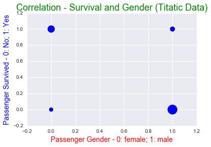

```python
# Causes plots to display within the notebook rather than in a new window
%pylab inline

# Since both 'Survived' and 'Gender' are binary variables,
# direct plot from p_df won't be able to demonstrate the number of survived (or perished) in each gender.
# So we construct a new data frame including a count of each 'Survived' & 'Gender' group.
df_survived_by_gender = p_df.groupby(['Survived', 'Gender'], as_index=False).count()

# df_survived_by_gender['Embarked'] is just a count represent the Num of passengers in each 'Survived'&'Gender' group
scaled_counts = df_survived_by_gender['Embarked']

plt.title("Correlation - Survival and Gender (Titatic Data)", fontsize=18,color='Green')
plt.xlabel('Passenger Gender - 0: female; 1: male', fontsize=14, color='red')
plt.ylabel("Passenger Survived - 0: No; 1: Yes",fontsize=14,color='blue')

plt.grid(True)

plt.scatter(x=df_survived_by_gender['Gender'], y=df_survived_by_gender['Survived'], s=scaled_counts)
plt.show()
```

From the scatter plot above, we somehow can see the fact that female passengers were more likely survived. And the correlation is a negative one given the variables definition (in terms of 0 or 1 choice of the two variables).

Using circle size that depict the represent the Number of passengers in each 'Survived'&'Gender' group is not the optimal choice as the visualization isn't very intuitive or obvious.

So try to use bar plot below instead:

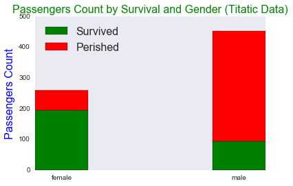

```python
# Causes plots to display within the notebook rather than in a new window
%pylab inline

# Since both 'Survived' and 'Gender' are binary variables,
# direct plot from p_df won't be able to demonstrate the number of survived (or perished) in each gender.
# So we construct a new data frame including a count of each 'Survived' & 'Gender' group.
df_survived_by_gender = p_df.groupby(['Survived', 'Gender'], as_index=False).count()

# Slice to a sub-dataframe that has only survived passengers count by gender
survived_by_gender = df_survived_by_gender.loc[df_survived_by_gender['Survived'] == 1]
survived_count_by_gender = survived_by_gender['Embarked']

# Slice to a sub-dataframe that has only perished passengers count by gender
perished_by_gender = df_survived_by_gender.loc[df_survived_by_gender['Survived'] == 0]
perished_count_by_gender = perished_by_gender['Embarked']

width = 0.30
plt.title("Passengers Count by Survival and Gender (Titatic Data)", fontsize=16,color='Green')

plt.ylabel("Passengers Count",fontsize=16,color='blue')

# be careful to set following ticks properly - match ticks label with grouping values
plt.xticks(survived_by_gender['Gender'] + width/2., ('female', 'male'))

plt.grid(False)

survived = plt.bar(survived_by_gender['Gender'], survived_count_by_gender, width, color='g')
perished = plt.bar(perished_by_gender['Gender'], perished_count_by_gender, width, color='r', bottom=survived_count_by_gender)

plt.legend((survived[0], perished[0]), ('Survived', 'Perished'), fontsize=16, loc=0)
plt.show()
```

From the bar plot above, we clearly see the fact that female passengers were more likely survived, while male passengers were more likely perished!

#### 2.2 Statistical analysis from correlation between 'Survived' and 'Pclass'

```
r = -0.359653
DF = 713
The two-tailed P value is less than 0.0001 < α
By criteria, this difference is considered to be extremely statistically significant.
In other words, P-value < 0.0001 indicates that the coefficient is very significant!
So given the α, here the Alternative Hypothesis - Ha holds true.
```

##### Visualization in plot

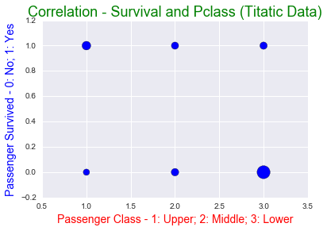

```python
# Causes plots to display within the notebook rather than in a new window
%pylab inline

# Since both 'Survived' and 'Pclass' are sparse-discreted variables (with 2 or 3 value choices),
# direct plot from p_df won't be able to demonstrate the number of survived (or perished) in each Pclass clearly.
# So we construct a new data frame including a count of each 'Survived' & 'Pclass' group.

df_survived_by_pclass = p_df.groupby(['Survived', 'Pclass'], as_index=False).count()

# df_survived_by_pclass['Embarked'] is just a count represent the Num of passengers in each 'Survived'&'Pclass' group
scaled_counts = df_survived_by_pclass['Embarked']

plt.title("Correlation - Survival and Pclass (Titatic Data)", fontsize=18,color='Green')
plt.xlabel('Passenger Class - 1: Upper; 2: Middle; 3: Lower', fontsize=14, color='red')
plt.ylabel("Passenger Survived - 0: No; 1: Yes",fontsize=14,color='blue')

plt.grid(True)

plt.scatter(x=df_survived_by_pclass['Pclass'], y=df_survived_by_pclass['Survived'], s=scaled_counts)
plt.show()
```

From the scatter plot above, we somehow can see the fact that upper class passengers were more likely survived. The correlation is a negative one given the variables definition (in terms of value choice of the two variables).

But the visualization isn't very intuitive or obvious.

Let's try to use bar plot below instead:

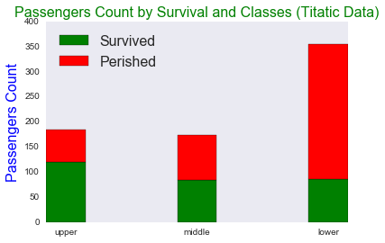

```python
# Causes plots to display within the notebook rather than in a new window
%pylab inline

# Since both 'Survived' and 'Pclass' are sparse-discreted variables (with 2 or 3 value choices),
# direct plot from p_df won't be able to demonstrate the number of survived (or perished) in each Pclass clearly.
# So we construct a new data frame including a count of each 'Survived' & 'Pclass' group.

df_survived_by_pclass = p_df.groupby(['Survived', 'Pclass'], as_index=False).count()

# Slice to a sub-dataframe that has only survived passengers count by pclass
survived_by_pclass = df_survived_by_pclass.loc[df_survived_by_pclass['Survived'] == 1]
survived_count_by_pclass = survived_by_pclass['Embarked']

# Slice to a sub-dataframe that has only perished passengers count by pclass
perished_by_pclass = df_survived_by_pclass.loc[df_survived_by_pclass['Survived'] == 0]
perished_count_by_pclass = perished_by_pclass['Embarked']

plt.title("Passengers Count by Survival and Classes (Titatic Data)", fontsize=16,color='Green')

plt.ylabel("Passengers Count",fontsize=16,color='blue')

# be careful to set following ticks properly - match ticks label with grouping values
plt.xticks(survived_by_pclass['Pclass'] + width/2., ('upper', 'middle', 'lower'))

plt.grid(False)
width = 0.30

survived = plt.bar(survived_by_pclass['Pclass'], survived_count_by_pclass, width, color='g')
perished = plt.bar(perished_by_pclass['Pclass'], perished_count_by_pclass, width, color='r', bottom=survived_count_by_pclass)

plt.legend((survived[0], perished[0]), ('Survived', 'Perished'), fontsize=16, loc=0)
plt.show()
```

From the bar plot above, we clearly see the fact that upper class passengers were more likely survived, while lower class passengers were more likely perished!

#### 2.3 Statistical analysis from correlation between 'Survived' and 'Fare'

```
r = 0.268189
DF = 713
The two-tailed P value is less than 0.0001 < α
By criteria, this difference is considered to be extremely statistically significant.
In other words, P-value < 0.0001 indicates that the coefficient is very significant!
So given the α, here the Alternative Hypothesis - Ha holds true.
```

##### Visualization in plot

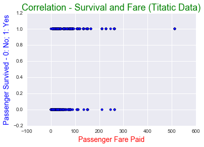

```python
# Causes plots to display within the notebook rather than in a new window
%pylab inline

# Since the 'Fare' is not a so sparse-discreted variables (relatively speaking),
# we should be able to visualize by direct plotting from p_df.

plt.title("Correlation - Survival and Fare (Titatic Data)", fontsize=18,color='Green')
plt.xlabel('Passenger Fare Paid', fontsize=14, color='red')
plt.ylabel("Passenger Survived - 0: No; 1: Yes",fontsize=14,color='blue')

plt.grid(True)

plt.scatter(p_df['Fare'], p_df['Survived'])
plt.show()
```

From the scatter plot above, we could see the trend that passengers paid higher fare were more likely survived. This correlation is a positive one.

To be more clear, let's try boxplot on Fare below:

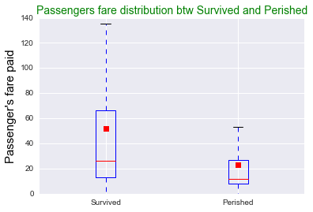

```python
# Causes plots to display within the notebook rather than in a new window
%pylab inline

# Slice to a sub-dataframe that has only survived passengers
survived = p_df.loc[p_df['Survived'] == 1]
# Series of 'Fare' from all survived passengers
survived_fares = survived['Fare']

# Slice to a sub-dataframe that has only perished passengers
perished = p_df.loc[p_df['Survived'] == 0]
# Series of 'Fare' from all perished passengers
perished_fares = perished['Fare']

plt.title("Passengers fare distribution btw Survived and Perished", fontsize=14,color='Green')
plt.ylabel("Passenger's fare paid",fontsize=15,color='black')

labels = ['Survived', 'Perished']
data = [survived_fares, perished_fares]

plt.boxplot(data, 0, '', labels=labels, showmeans=True)
plt.show()
```

From the boxplot above, we could see the fact that survived passengers more likely paid higher fare.

#### 2.4 Statistical analysis from correlation between 'Survived' and 'Parch'

```
r = 0.093317
DF = 713
The two-tailed P-value = 0.0125 > α
By criteria, this difference is considered to be statistically marginal insignificant.
In other words, P-value > α indicates that the coefficient is not significant!
So given the α, here the Null Hypothesis - H0 holds true.
```

##### Visualization in scatter graph

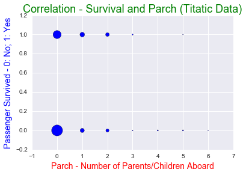

```python
# Causes plots to display within the notebook rather than in a new window
%pylab inline

# Since both 'Survived' and 'Parch' are sparse-discreted variables (with 2 to a few value choices),
# direct plot from p_df won't be able to demonstrate the number of survived (or perished) in each Parch clearly.
# So we construct a new data frame including a count of each 'Survived' & 'Parch' group.

df_survived_by_parch = p_df.groupby(['Survived', 'Parch'], as_index=False).count()

# df_survived_by_parch['Embarked'] is just a count represent the Num of passengers in each 'Survived'&'Parch' group
scaled_counts = df_survived_by_parch['Embarked']

plt.title("Correlation - Survival and Parch (Titatic Data)", fontsize=18,color='Green')
plt.xlabel('Parch - Number of Parents/Children Aboard', fontsize=14, color='red')
plt.ylabel("Passenger Survived - 0: No; 1: Yes",fontsize=14,color='blue')

plt.grid(True)

plt.scatter(x=df_survived_by_parch['Parch'], y=df_survived_by_parch['Survived'], s=scaled_counts)
plt.show()
```

From the scatter plot above, we could hardly see any correlation between the two variables. It is hard to tell passengers of what Parch values were more likely survived.

#### 2.5 Statistical analysis from correlation between 'Survived' and 'Age'

```
r = -0.077221
DF = 713
The two-tailed P-value = 0.0390 > α
By criteria, this difference is considered to be statistically insignificant.
In other words, P-value > α indicates that the coefficient is not significant!
So given the α, here the Null Hypothesis - H0 holds true.
```

##### Visualization in plot

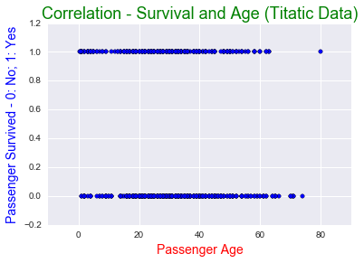

```python
# Causes plots to display within the notebook rather than in a new window
%pylab inline

# Since the 'Age' is not a so sparse-discreted variables (relatively speaking),
# we should be able to visualize by direct plotting from p_df.

plt.title("Correlation - Survival and Age (Titatic Data)", fontsize=18,color='Green')
plt.xlabel('Passenger Age', fontsize=14, color='red')
plt.ylabel("Passenger Survived - 0: No; 1: Yes",fontsize=14,color='blue')

plt.grid(True)

plt.scatter(p_df['Age'], p_df['Survived'])
plt.show()
```

From the scatter plot above, we could hardly see any correlation between the two variables. It is hard to tell passengers of what Age ranges were more likely survived, or any trend (since it is over-plotted).

To be more clear, let's try boxplot below instead:

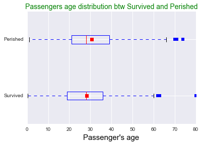

```python
# Causes plots to display within the notebook rather than in a new window
%pylab inline

# Slice to a sub-dataframe that has only survived passengers
survived = p_df.loc[p_df['Survived'] == 1]
# Series of 'Age' from all survived passengers
survived_ages = survived['Age']

# Slice to a sub-dataframe that has only perished passengers
perished = p_df.loc[p_df['Survived'] == 0]
# Series of 'Age' from all perished passengers
perished_ages = perished['Age']

plt.title("Passengers age distribution btw Survived and Perished", fontsize=14,color='Green')
plt.xlabel("Passenger's age",fontsize=15,color='black')

labels = ['Survived', 'Perished']
data = [survived_ages, perished_ages]

plt.boxplot(data, 0, 'rs', 0, labels=labels, showmeans=True)
plt.show()
```

From the boxplot above, we could still see that younger passengers were more likely survived but slightly, since Survived's mean 'Age' is slightly lower than Perished.

#### 2.6 Statistical analysis from correlation between 'Survived' and 'SibSp'

```
r = -0.017358
DF = 713
The two-tailed P-value = 0.6431 >> α
By criteria, this difference is considered to be very statistically insignificant.
In other words, P-value >> α indicates that the coefficient is very insignificant!
So given the α, here the Null Hypothesis - H0 holds true.
```

##### Visualization in scatter graph

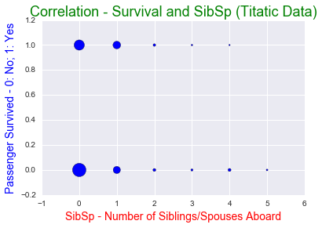

```python
# Causes plots to display within the notebook rather than in a new window
%pylab inline

# Since both 'Survived' and 'SibSp' are sparse-discreted variables (with 2 to a few value choices),
# direct plot from p_df won't be able to demonstrate the number of survived (or perished) in each SibSp clearly.
# So we construct a new data frame including a count of each 'Survived' & 'SibSp' group.

df_survived_by_sibsp = p_df.groupby(['Survived', 'SibSp'], as_index=False).count()

# df_survived_by_sibsp['Embarked'] is just a count represent the Num of passengers in each 'Survived'&'SibSp' group
scaled_counts = df_survived_by_sibsp['Embarked']

plt.title("Correlation - Survival and SibSp (Titatic Data)", fontsize=18,color='Green')
plt.xlabel('SibSp - Number of Siblings/Spouses Aboard', fontsize=14, color='red')
plt.ylabel("Passenger Survived - 0: No; 1: Yes",fontsize=14,color='blue')

plt.grid(True)

plt.scatter(x=df_survived_by_sibsp['SibSp'], y=df_survived_by_sibsp['Survived'], s=scaled_counts)
plt.show()
```

From the scatter plot above, it is almost impossible to tell any correlation between the two variables.